# Introduction to Basic Programming

- About this course
- Acknowledgements
- Base Programming
- Functions structure
- Functions writing
- Conditionals
- Loops
- Functionals
- Advanced Topics
- Reporting with R Markdown

# Functions structure

When working with R we all make constant use of functions and, when developing, we create new functions so that functions look like very familiar R objects. Nevertheless, understanding the theory and the rationals underlying R functions may help to create much more efficient and possibly elegant coding.

We can create and assign functions to a variable name as we do with any other object:

```r
f <- function(x, y = 0) {
  z <- x + y
  z
}
```

Eventually, we can delete any function with the usual call to `rm()` or `remove()`

Functions are objects with three basic components:

- a formal arguments list
- a body
- an environment.

```r
formals(f)
```

```
## $x
##
##
## $y
## [1] 0
```

```r
body(f)
```

```
## {
##     z <- x + y
##     z
## }
```

```r
environment(f)
```

```
## <environment: R_GlobalEnv>
```

## Formals

Formals are the formal arguments of a function returned as an object of class `pairlist` where a `pairlist` can be thought as something similar to a list with an important difference:

```r
is.null(pairlist())
```

```
## [1] TRUE
```

```r
is.null(list())
```

```
## [1] FALSE
```

that is: a `pairlist` of length zero is `NULL` while a `list` is not.

When we call a function, formals arguments can be specified by position or by name and we can mix positional matching with matching by name so that the following are equivalent:

```r
mean(x = 1:5, trim = 0.1)
```

```
## [1] 3
```

```r
mean(1:5, trim = 0.1)
```

```
## [1] 3
```

```r
mean(x = 1:5, 0.1)
```

```
## [1] 3
```

```r
mean(1:5, 0.1)
```

```
## [1] 3
```

```r
mean(trim = 0.1, x = 1:5)
```

```
## [1] 3
```

Along with position and name, we can also specify formals by partial matching so that:

```r
mean(1:5, tr = 0.1)
```

```
## [1] 3
```

```r
mean(tr = 0.1, x = 1:5)
```

```
## [1] 3
```

would work anyway.

Functions formals may also have the construct `symbol = default`, that unless differently specified, forces any argument to be used with its default value.

Specifically, function `mean()` also have a third argument `na.rm` that defaults to `FALSE` and, as a result passing vectors with `NA` values to `mean()` returns `NA`

```r
mean(c(1, 2, NA))
```

```
## [1] NA
```

While, by specifying `na.rm=TRUE` we get the mean of all non missing elements of vector `x`.

```r
mean(c(1, 2, NA), na.rm = TRUE)
```

```
## [1] 1.5
```

The order `R` uses for matching formals against value is:

1. Check for exact match for a named argument
2. Check for a partial match
3. Check for a positional match

Formals of a function are normally used within functions by the internal `R` evaluator but, we can use function `formals()` to expose formals explicitly.

```r
formals(f)
```

```
## $x
##
##
## $y
## [1] 0
```

`args()` is another function that displays the formals in a more user friendly fashion. Actually, `args(fun)` returns a function with the same arguments as `fun` but with an empty body.

```r
args(f)
```

```
## function (x, y = 0)
## NULL
```

Surely, for programming purposes, `formals()` is a better choice as it returns a simple `pairlist` that can be handled as a list:

```r
is.list(formals(mean))
```

```
## [1] TRUE
```

The “`...`” argument of a function is a special argument and can contain any number of `symbol=value` arguments . The “`...`” argument is transformed by `R` into a list that is simply added to the `formals` list:

```r
h <- function (x, ...) {0}
formals(h)
```

[output not shown]

The “`...`” argument can be used if the number of arguments is unknown. Suppose we want to define a function that counts the number of rows of any given number of data frames we could write:

```r
count_rows <- function(...) {
  list <- list(...)
  lapply(list, nrow)
}

count_rows(airquality, cars)
```

```
## [[1]]
## [1] 153
##
## [[2]]
## [1] 50
```

Similarly, the “`...`” arguments becomes very handy when the “`...`” arguments will be passed on to another function as it often happened when calling `ggplot2` functions from within another function. The following example shows a function which draws a line plot, where additional graphics parameters are passed via “`...`”:

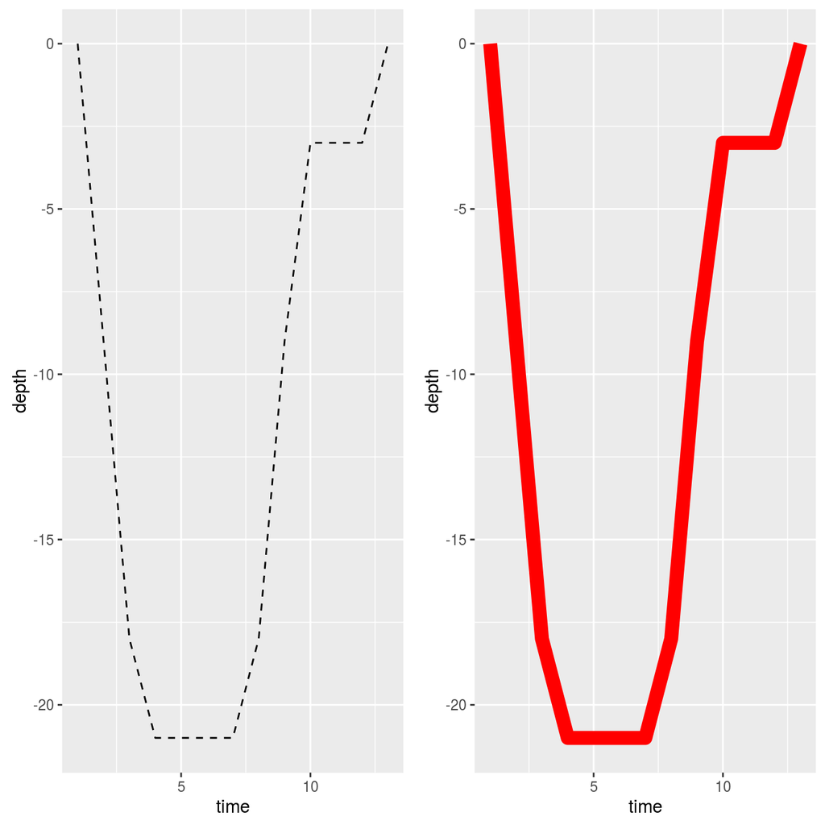

```r
require(ggplot2)

# Function
plot_depth <-  function(df, time_var_name, depth_var_name, ...){
  ggp <- ggplot(data=df, mapping=aes_string(x=time_var_name, y= depth_var_name)) +
          geom_line(...)
  return(ggp)
}

# Example
time <-  1:13
depth <-  c(0,-9,-18,-21,-21,-21,-21,-18,-9,-3,-3,-3,0)
df <- data.frame(time=time, depth=depth)

ggp1 <- plot_depth(df, time_var_name = "time", depth_var_name = "depth", linetype = 2)
ggp2 <- plot_depth(df, time_var_name = "time", depth_var_name = "depth", size = 4, col = "red")

gridExtra::grid.arrange(ggp1, ggp2, ncol=2)
```

## Body of a function

The body of a function is a parsed R statement. In practice, this implies that the body of a function needs to be correct from a formal point of view but no evaluation of the body of a function occurred yet.

As a result, this function would return an error:

```r
wrong <- function(x) {x =}
```

as its body is not a correct `R` statement.

While this function:

```r
right <- function(x){x+y}
```

is accepted by `R` as is formally correct even thought, except under specific circumstances, will always return an error:

```r
right(x = 2)
```

```
## Error in right(x = 2): object 'y' not found
```

The body of a function, is usually a collection of statements in braces but it can be a single statement, a symbol or even a constant.

## Environment of a function

Environments are a fundamental concept in R and their knowledge is essential for advanced programming.

Environments are not threated here, but the following fundamental concepts:

- The environment of a function is the environment that was active at the time that the function was created. Generally, for user defined function, the Global environment:

  ```r
  f <- function(x){x+1}
  environment(f)
  ```

  ```
  ## <environment: R_GlobalEnv>
  ```

  or, when a function is defined within a package, the environment associated to that package:

  ```r
  environment(mean)
  ```

  ```
  ## <environment: namespace:base>
  ```

- Objects defined within a function, exists in the environment of the function itself.

  ```r
  f <- function(x){x+1}
  x
  ```

  ```
  ## Error in eval(expr, envir, enclos): object 'x' not found
  ```